# WHITE WINE EDA BY ELAD SHAHAR

## Investigating groups of interest

### density, alcohol residual sugar and total sulfur dioxide.

The strongest correlations we found in our correlation matrix are density to residual sugar and density to alcohol. I will chart the relations

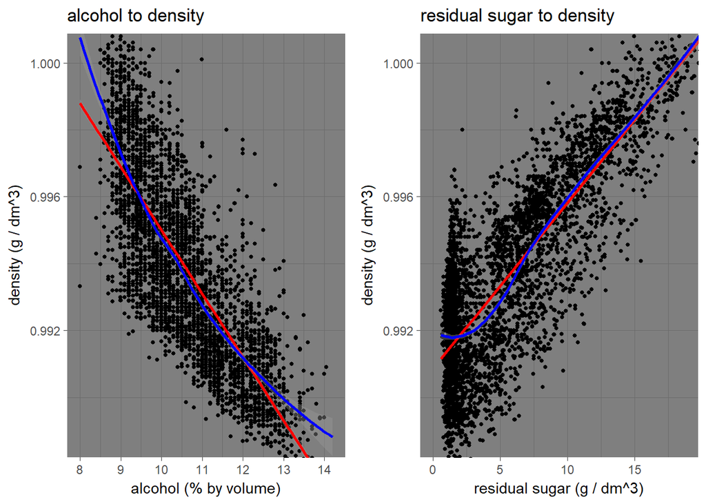

The red lines in the plot are linear lines of best fit while the blue are rolling means

There is clear negative correlation between density and alcohol, leading us to look for a reasonable explantion for this correlation. similiary, density and residual sugar are postively correlated. I will add some background on the wine making process from the article “sugars in wine”" in wikipedia: “During fermentation, glucose is consumed first by the yeast and converted into alcohol. A winemaker that chooses to halt fermentation will be left with a wine that is high in fructose and notable residual sugars.”" I suspect that according to the explanation above, generally the higher the residual sugar level is, the lower the alcohol level in the wine. let us chart this relationship

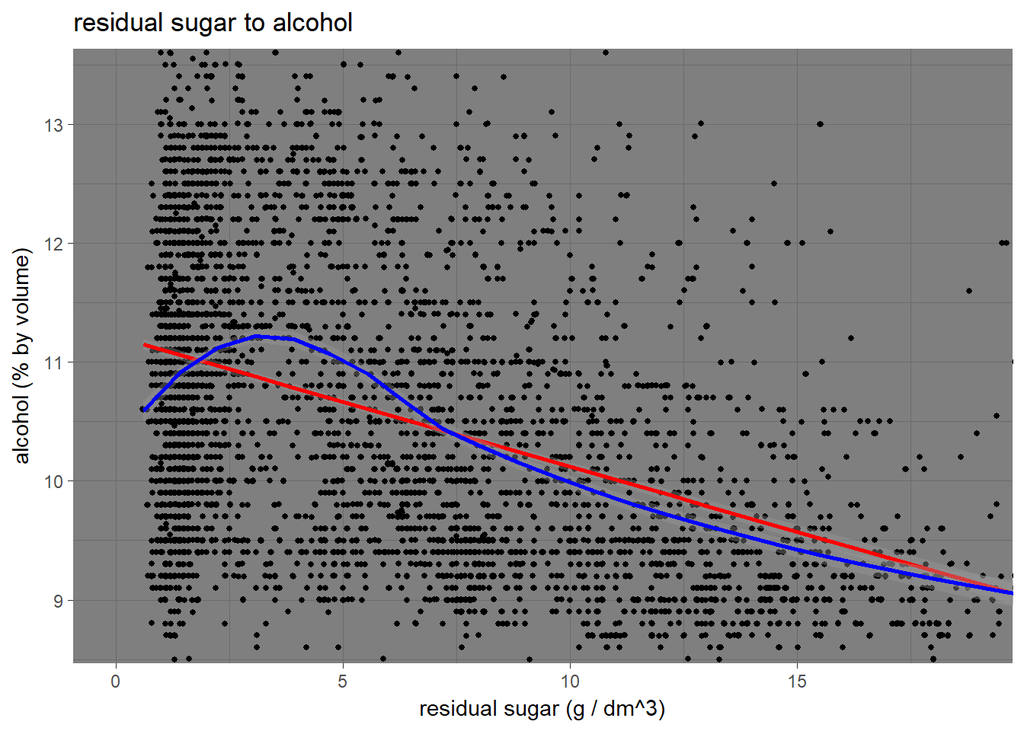

```
##
##  Pearson's product-moment correlation
##
## data:  residual.sugar and alcohol
## t = -35.321, df = 4896, p-value < 2.2e-16
## alternative hypothesis: true correlation is not equal to 0
## 95 percent confidence interval:
##  -0.4726723 -0.4280267
## sample estimates:
##        cor
## -0.4506312
```

We can see a significant negative correlation between residual sugar and alcohol as expected. Considering that sugar is denser than alcohol we can assume at least part of the correlation corresponds to this rule of thumb. The lower the percentage of alcohol, the more sugar is still in the fluid = heavier liquid

other interesting relationships to investigate are total sulfur dioxide to density and alcohol.

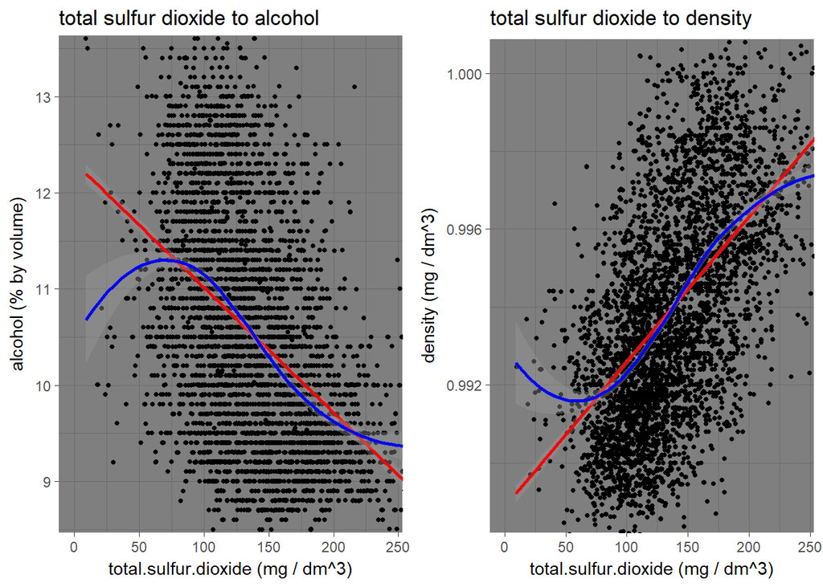

Total sulfur dioxide has a negative correlation to alcohol meaning that in general as total sulfur dioxide levels increase, alcohol levels decreases. Total sulfur dioxide also has a positive correlation to density meaning that in general as total sulfur dioxide levels increases, density increases as well. I also found that both residual sugar and total sulfur dioxide have the same correlation to alcohol (-0.45) and a signficant correlation to each other (0.4).

As SO2 is both a a natural by-product of the fermentation process and a common additive used heavily as an antioxidant we would expect to see some level of SO2 in most wines. indeed all observations in our dataset include at least a little sulfur dioxide. It is interesting to note that there is a trend of sulphates free wines due to concerns about detrimental health effects SO2 in wine, a more recent dataset would perhaps show lower average SO2 levels in wines.

### free sulfur dioxide to total sulfur dioxide

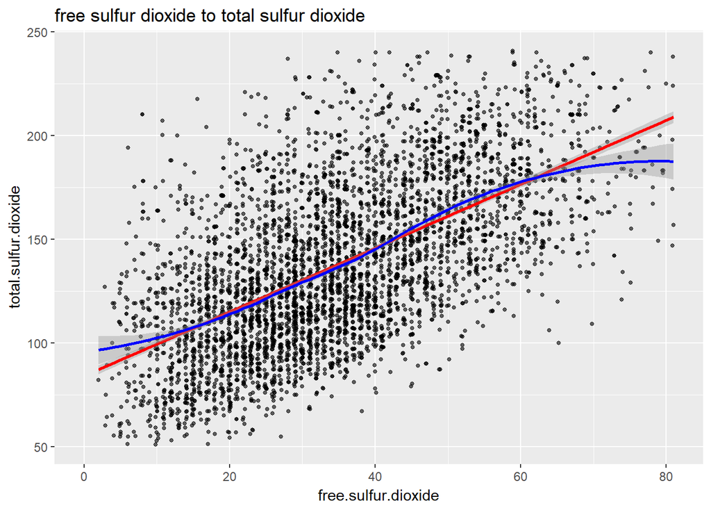

```
##
##  Pearson's product-moment correlation
##
## data:  free.sulfur.dioxide and total.sulfur.dioxide
## t = 54.645, df = 4896, p-value < 2.2e-16
## alternative hypothesis: true correlation is not equal to 0
## 95 percent confidence interval:
##  0.5977994 0.6326026
## sample estimates:
##      cor
## 0.615501
```

We have removed the top and buttom 1% of observations to reduce outlier effect we can see a strong positive correlation between free sulfur dioxide and total sulfur dioxide. This seems logical as free sulfur dioxide is part of total sulfur dioxide.

I will run a correlation between quality and the attribute created in the univariate section sulfur.dioxide.ratio

```
##
##  Pearson's product-moment correlation
##
## data:  quality and sulfur.dioxide.ratio
## t = 14.076, df = 4896, p-value < 2.2e-16
## alternative hypothesis: true correlation is not equal to 0
## 95 percent confidence interval:
##  0.1701474 0.2239834
## sample estimates:
##       cor
## 0.1972141
```

the sulfur.dioxide.ratio attribute has slightly stronger correlation to quality (our attribute of interest) than the sum of both correlations. The resulitng correlation is still weak and we will not pursue use of the new attribute sulfur.dioxide.ratio further.

# Bivariate Analysis

### Talk about some of the relationships you observed in this part of the investigation. How did the feature(s) of interest vary with other features in the dataset?

I have plotted each attribute against quality and the strongest correlation has been between quality and alcohol. Density, residual sugar and total sulfur dioxide have all significant correlation to each other and thus to alcohol which is closly correlated to density. Further investigation into the attributes led us to a theory that white wine of good quality tend to have a high alcohol level, low residual sugar , low total sulfur dioxide and lower density.

### Did you observe any interesting relationships between the other features (not the main feature(s) of interest)?

There are several interesting relationships. the first and most interesting is a significant correlation between alcohol and quality which is our attribute of interest. Considering that alcohol is strongly correlated to residual sugar, to total sulfur dioxide and to density, I predict that these attributes will contribute the most to any model we may apply.

density is signficantly correlated to total sulfur dioxide, alcohol and residual sugar which fits in with what we learned in our investigation on the wine fermentation process.

An additional significant relationship is free sulfur dioxide to total sulfur dioxide, this relationship is strongly positve (pearson’s 0.62) and is somewhat expected as free sulfur dioxide is a component of total sulfur dioxide.

# Multivariate Plots Section

I will look at some of the plots with 2 variable and attempt to find interesting information with an additional variable

### density to alcohol and residual sugar with 3 variables

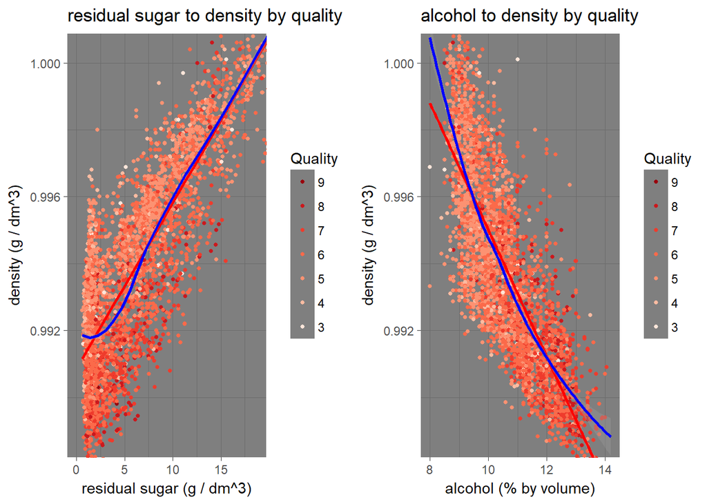

For residual sugar to density We can see that most good wines (7-9) are below the linear line of best fitfor the residual sugar to density plot. This shows us that good wines in the dataset tend to be less dense than lower quality wines with the same amount of residual sugar.this information was not easily visible without the quality variable added to the plot.

### Residual sugar to alcohol revisited with 3 variables

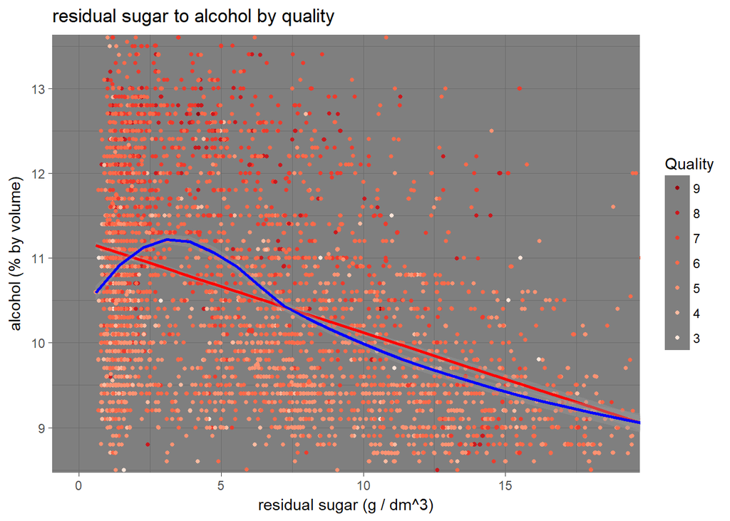

In this chart as well with the addition of quality as the 3rd variable we can an interesting trend, in general higher quality wines have higher alcohol content than lower quality wines with the same residual sugar levels. This would not be visible without the 3rd variable ### Model

I have prepared a model for investigating the quality

```
##
## Calls:
## m1: lm(formula = quality ~ alcohol, data = wq)
## m2: lm(formula = quality ~ alcohol + residual.sugar, data = wq)
## m3: lm(formula = quality ~ alcohol + residual.sugar + total.sulfur.dioxide,
##     data = wq)
## m4: lm(formula = quality ~ alcohol + residual.sugar + total.sulfur.dioxide +
##     density, data = wq)
## m5: lm(formula = quality ~ alcohol + residual.sugar + total.sulfur.dioxide +
##     density + volatile.acidity, data = wq)
## m6: lm(formula = quality ~ alcohol + residual.sugar + total.sulfur.dioxide +
##     density + volatile.acidity + sulphates, data = wq)
## m7: lm(formula = quality ~ alcohol + residual.sugar + total.sulfur.dioxide +
##     density + volatile.acidity + sulphates + citric.acid, data = wq)
## m8: lm(formula = quality ~ alcohol + residual.sugar + total.sulfur.dioxide +
##     density + volatile.acidity + sulphates + citric.acid + pH,
##     data = wq)
##
## ========================================================================================================================================
##                              m1            m2            m3            m4            m5            m6            m7            m8
## ----------------------------------------------------------------------------------------------------------------------------------------
##   (Intercept)               2.582***      2.021***      2.048***     93.661***     82.245***    101.668***    100.095***    122.761***
##                            (0.098)       (0.117)       (0.139)      (12.665)      (12.231)      (12.559)      (12.736)      (13.185)
##   alcohol                   0.313***      0.354***      0.352***      0.246***      0.288***      0.263***      0.265***      0.231***
##                            (0.009)       (0.010)       (0.011)       (0.018)       (0.018)       (0.018)       (0.018)       (0.019)
##   residual.sugar                          0.022***      0.022***      0.054***      0.053***      0.061***      0.061***      0.072***
##                                          (0.002)       (0.003)       (0.005)       (0.005)       (0.005)       (0.005)       (0.005)
##   total.sulfur.dioxide                                 -0.000         0.000         0.001**       0.001*        0.001*        0.001*
##                                                        (0.000)       (0.000)       (0.000)       (0.000)       (0.000)       (0.000)
##   density                                                           -91.314***    -79.761***    -99.384***    -97.794***   -121.921***
##                                                                     (12.623)      (12.191)      (12.528)      (12.709)      (13.224)
##   volatile.acidity                                                                 -2.093***     -2.050***     -2.064***     -2.002***
##                                                                                    (0.109)       (0.109)       (0.111)       (0.111)
##   sulphates                                                                                       0.630***      0.631***      0.581***
##                                                                                                  (0.099)       (0.099)       (0.099)
##   citric.acid                                                                                                  -0.069         0.067
##                                                                                                                (0.093)       (0.095)
##   pH                                                                                                                          0.495***
##                                                                                                                              (0.078)
## ----------------------------------------------------------------------------------------------------------------------------------------
##   R-squared                 0.190         0.202         0.202         0.210         0.265         0.271         0.272         0.277
##   adj. R-squared            0.190         0.202         0.201         0.210         0.265         0.271         0.271         0.276
##   sigma                     0.797         0.791         0.791         0.787         0.759         0.756         0.756         0.753
##   F                      1146.395       619.354       412.870       325.984       353.570       303.756       260.417       234.652
##   p                         0.000         0.000         0.000         0.000         0.000         0.000         0.000         0.000
##   Log-likelihood        -5839.391     -5802.158     -5802.097     -5776.042     -5599.111     -5578.948     -5578.671     -5558.805
##   Deviance               3112.257      3065.298      3065.221      3032.783      2821.404      2798.270      2797.953      2775.348
##   AIC                   11684.782     11612.317     11614.193     11564.084     11212.223     11173.897     11175.341     11137.609
##   BIC                   11704.272     11638.303     11646.676     11603.064     11257.699     11225.869     11233.810     11202.575
##   N                      4898          4898          4898          4898          4898          4898          4898          4898
## ========================================================================================================================================
```

The best prediction attributes were alcohol, residual sugar, volatile acidity,density, total sulfur dioxide, sulphates ,citric acid and pH The best fit for the model I found was 0.277, a weak R squared value. This may indicate that a linear model is not the best model for this dataset.

# Multivariate Analysis

### Talk about some of the relationships you observed in this part of the investigation. Were there features that strengthened each other in terms of looking at your feature(s) of interest?

The most interesting interactions between attributes for me are those between density, alcohol and residual sugar. I saw a clear correlation and when I read further into the wine making process understood that sugar is consumed during the fermentation process to produce alcohol. the more sugar in the wine, the less alcohol and as sugar is denser than alcohol, the higher the density.

### Were there any interesting or surprising interactions between features?

An interesting interaction for me was the strong correlation between density and residual sugar ( the highest in our dataset). The more sugar in the wine the higher the density. This coincides with the process of fermenting wine consuming sugar to produce alcohol which is less dense than sugar.

### OPTIONAL: Did you create any models with your dataset? Discuss the strengths and limitations of your model.

I have created 8 models with the first featuring alcohol as the predictor of quality and introducing additional attributes onewith each consequative model. the 8th model including alcohol, volatile acidity, residual sugar, total sulfate dioxide, density, sulphates, citric acid and pH had the highest R squared value at 0.277 our models 0.277 value is quite low which make it unlikely to be useful as a predictor of wine quality. Perhaps a larger dataset with a more balanced distribution across quality values of sample wines will allow better modeling.

# Final Plots and Summary

### Plot One

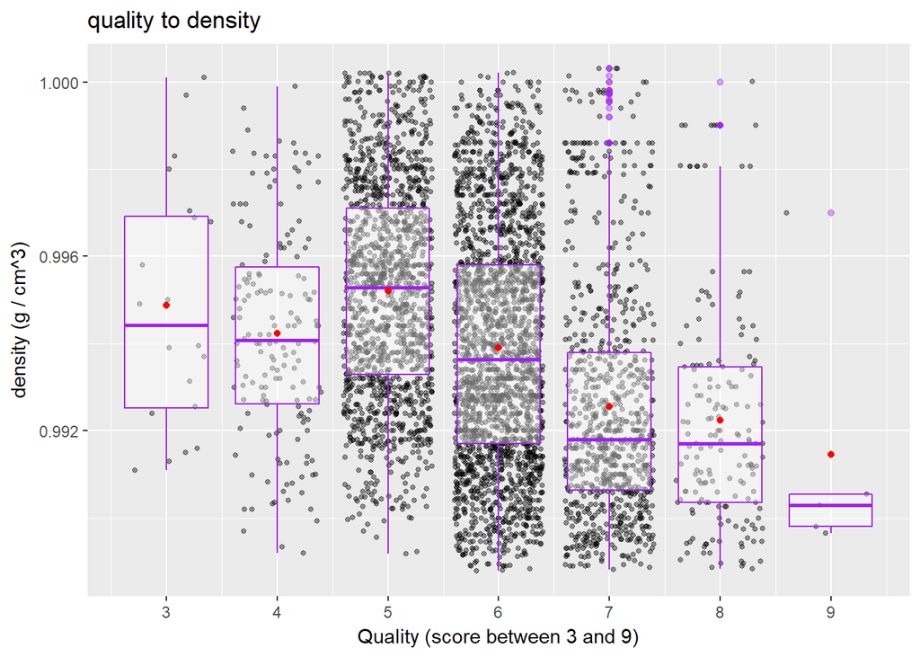

### Description One

This plot shows the relation between quality and density, while not the strongest correlation of quality (that would be alcohol at Pearson’s coefficient of 0.44) it shows a signficant negative correlation of -0.3 Pearson’s coefficient. To provide readability I’ve removed the top and buttom 1% of density results to reduce outlier effect. This plot also shows us a pattern that repeats across other relationships in which the “bad” quality wines go against the trend of the other two groups (“average”" and “good”). Due to the small number of observations with “bad” quality it is difficult to compare with the more numourous observations across other quality groups. It would be interesting to analyze a dataset with observations more evenly distributed across quality values.

### Plot Two

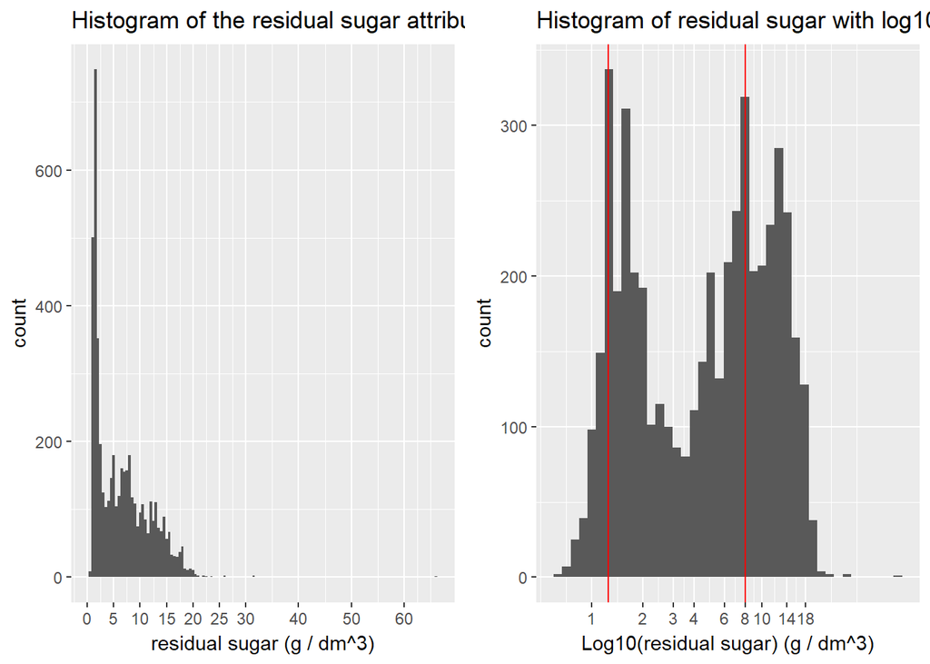

### Description Two

I chose the residual sugar histogram exploring residual sugar in a univariate plot. residual sugar has a positively skewed distribution, to improve readabilty we have applied a log10 scale transformation. In the transformed plot (on the right) we can see that now distribution appears bimodal with peaks around 1.25 and 8 (vertical red lines on the plot)

### Plot Three

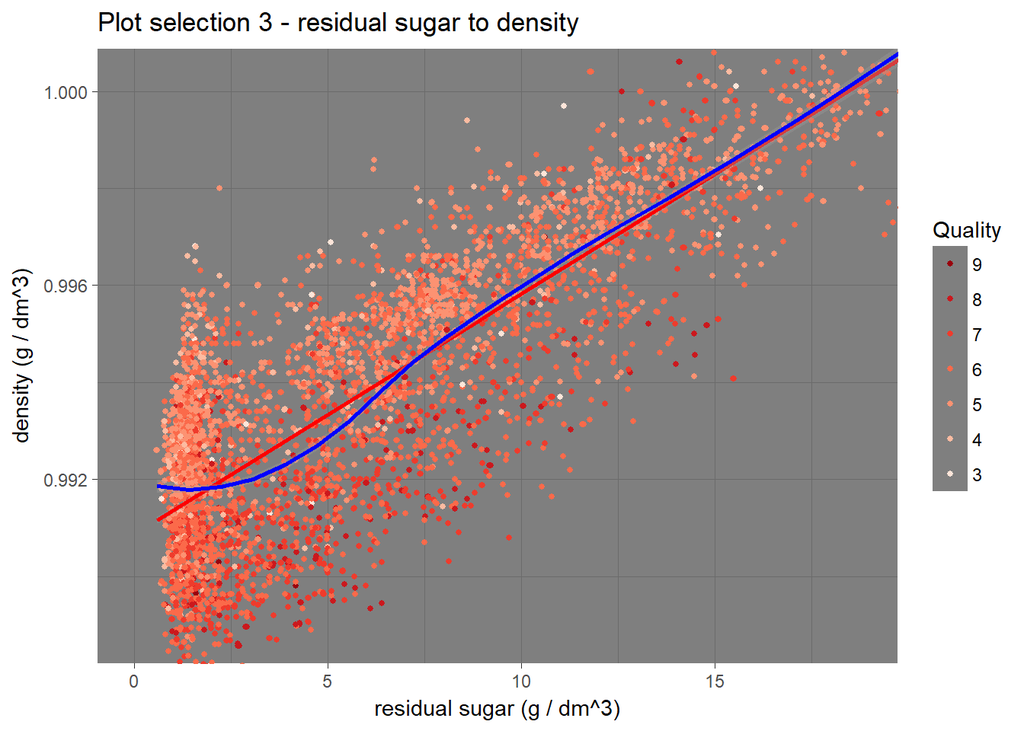

### Description Three

I found this plot interesting because it clearly shows the strong positive correlation between residual sugar and density (highest in this dataset at R^2 0.84) An additional insight I gained from adding the third variable, quality, was that better quality wines tended to have lower density than for worse quality wine with the same residual sugar level.

# Reflection

The EDA process for the white wine dataset was very useful for a deeper understanding of data exploration methods. Moving from univariate to multivariate plots helps with a methodical exploration of the dataset and its correlations.

The most interesting relationship for me lies between alcohol, density and residual sugar, investigating these correlations led us to a deeper understanding of the wine making process and the interactions between some of the wine’s components.

I also tried builidng a linear model for quality prediction but the R^2 value was quite low (0.277). this can indicate that for this dataset a non linear model would perform better.

It would be very interesting to a larger dataset with a more even spread of observations across quality values. In several cases the extreme quality wines go against the trend (mostly bad wines at 3 to 4). the amount of observations from this quality group is extremely low, less than 5%. Ideally we would be able to compare additional attributes such as price points, brands, grape type, region and other relevant infromation.

It would also be interesting to have a more updated dataset. There are world trends such as sulphates free wines which may impact the use of certain chemicals in the wine making process and accordingly lead to a change in commercial wines composition.

# references

https://s3.amazonaws.com/udacity-hosted-downloads/ud651/wineQualityInfo.txt  
http://www.vinhoverde.pt/en/  
http://illumin.usc.edu/119/from-the-vine-to-the-table-winemaking-explained/  
https://en.wikipedia.org/wiki/Sugars_in_wine  
https://winefolly.com/update/sugar-in-wine-misunderstanding/  
https://en.wikipedia.org/wiki/Fermentation_(wine)